# Risk Factor Analysis

## Outcome Variable

**Outcome Variable:** haz

## Predictor Variables

**Intervention Variable:** fhtcm

**Adjustment Set:**

unadjusted

## Stratifying Variables

The analysis was stratified on these variable(s):

- agecat
- studyid
- country

## Data Summary

| agecat | studyid | country | fhtcm | n_cell | n |
| --- | --- | --- | --- | --- | --- |
| Birth | COHORTS | GUATEMALA | >=167 cm | 29 | 206 |
| Birth | COHORTS | GUATEMALA | <162 cm | 121 | 206 |
| Birth | COHORTS | GUATEMALA | [162-167) cm | 56 | 206 |
| Birth | Keneba | GAMBIA | >=167 cm | 772 | 1167 |
| Birth | Keneba | GAMBIA | <162 cm | 87 | 1167 |
| Birth | Keneba | GAMBIA | [162-167) cm | 308 | 1167 |
| Birth | PROBIT | BELARUS | >=167 cm | 11742 | 12535 |
| Birth | PROBIT | BELARUS | <162 cm | 168 | 12535 |
| Birth | PROBIT | BELARUS | [162-167) cm | 625 | 12535 |
| Birth | SAS-CompFeed | INDIA | >=167 cm | 343 | 746 |
| Birth | SAS-CompFeed | INDIA | <162 cm | 190 | 746 |
| Birth | SAS-CompFeed | INDIA | [162-167) cm | 213 | 746 |
| 6 months | COHORTS | GUATEMALA | >=167 cm | 45 | 336 |
| 6 months | COHORTS | GUATEMALA | <162 cm | 197 | 336 |
| 6 months | COHORTS | GUATEMALA | [162-167) cm | 94 | 336 |
| 6 months | Keneba | GAMBIA | >=167 cm | 979 | 1511 |
| 6 months | Keneba | GAMBIA | <162 cm | 113 | 1511 |
| 6 months | Keneba | GAMBIA | [162-167) cm | 419 | 1511 |
| 6 months | PROBIT | BELARUS | >=167 cm | 11146 | 11894 |
| 6 months | PROBIT | BELARUS | <162 cm | 156 | 11894 |
| 6 months | PROBIT | BELARUS | [162-167) cm | 592 | 11894 |
| 6 months | SAS-CompFeed | INDIA | >=167 cm | 369 | 807 |
| 6 months | SAS-CompFeed | INDIA | <162 cm | 194 | 807 |
| 6 months | SAS-CompFeed | INDIA | [162-167) cm | 244 | 807 |
| 6 months | SAS-FoodSuppl | INDIA | >=167 cm | 102 | 372 |
| 6 months | SAS-FoodSuppl | INDIA | <162 cm | 148 | 372 |
| 6 months | SAS-FoodSuppl | INDIA | [162-167) cm | 122 | 372 |
| 24 months | COHORTS | GUATEMALA | >=167 cm | 70 | 526 |
| 24 months | COHORTS | GUATEMALA | <162 cm | 307 | 526 |
| 24 months | COHORTS | GUATEMALA | [162-167) cm | 149 | 526 |
| 24 months | Keneba | GAMBIA | >=167 cm | 821 | 1297 |
| 24 months | Keneba | GAMBIA | <162 cm | 97 | 1297 |
| 24 months | Keneba | GAMBIA | [162-167) cm | 379 | 1297 |
| 24 months | PROBIT | BELARUS | >=167 cm | 3445 | 3670 |
| 24 months | PROBIT | BELARUS | <162 cm | 53 | 3670 |
| 24 months | PROBIT | BELARUS | [162-167) cm | 172 | 3670 |

The following strata were considered:

- agecat: 24 months, studyid: COHORTS, country: GUATEMALA
- agecat: 24 months, studyid: Keneba, country: GAMBIA
- agecat: 24 months, studyid: PROBIT, country: BELARUS
- agecat: 6 months, studyid: COHORTS, country: GUATEMALA
- agecat: 6 months, studyid: Keneba, country: GAMBIA
- agecat: 6 months, studyid: PROBIT, country: BELARUS
- agecat: 6 months, studyid: SAS-CompFeed, country: INDIA
- agecat: 6 months, studyid: SAS-FoodSuppl, country: INDIA
- agecat: Birth, studyid: COHORTS, country: GUATEMALA
- agecat: Birth, studyid: Keneba, country: GAMBIA
- agecat: Birth, studyid: PROBIT, country: BELARUS
- agecat: Birth, studyid: SAS-CompFeed, country: INDIA

## Methods Detail

We’re interested in the causal parameters $E[Y_a]$ for all values of $a \in \mathcal{A}$. These parameters represent the mean outcome if, possibly contrary to fact, we intervened to set all units to have $A=a$. Under the randomization and positivity assumptions, these are identified by the statistical parameters $\psi_a=E_W[E_{Y|A,W}(Y|A=a,W)]$. In addition, we’re interested in the mean of $Y$, $E[Y]$ under no intervention (the observed mean). We will estimate these parameters by using SuperLearner to fit the relevant likelihood factors – $E_{Y|A,W}(Y|A=a,W)$ and $p(A=a|W)$, and then updating our likelihood fit using a joint TMLE.

For unadjusted analyses ($W=\{\}$), initial likelihoods were estimated using Lrnr_glm to estimate the simple $E(Y|A)$ and Lrnr_mean to estimate $p(A)$. For adjusted analyses, a small library containing Lrnr_glmnet, Lrnr_xgboost, and Lrnr_mean was used.

Having estimated these parameters, we will then use the delta method to estimate relative risks and attributable risks relative to a prespecified baseline level of $A$.

# Results Detail

## Results Plots

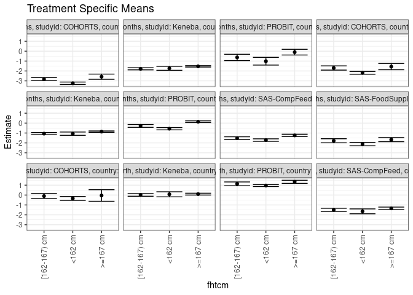

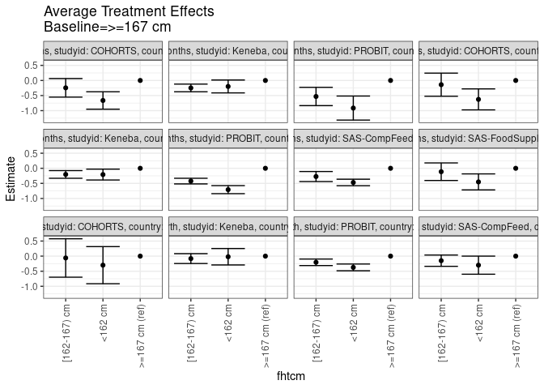

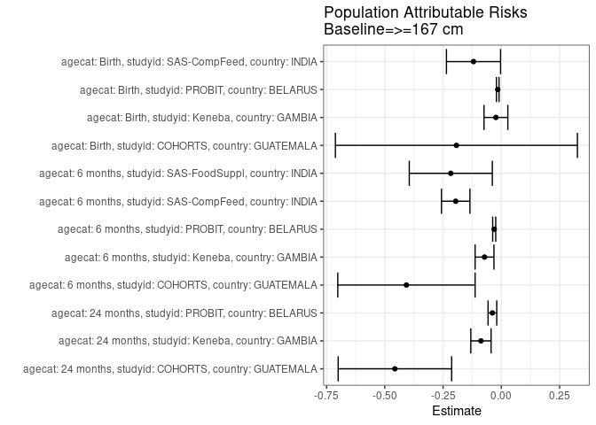

## Results Table

### Parameter: TSM

| agecat | studyid | country | intervention_level | baseline_level | estimate | ci_lower | ci_upper |
| --- | --- | --- | --- | --- | --- | --- | --- |
| Birth | COHORTS | GUATEMALA | >=167 cm | NA | -0.0441379 | -0.6279906 | 0.5397147 |
| Birth | COHORTS | GUATEMALA | <162 cm | NA | -0.3439669 | -0.5371609 | -0.1507730 |
| Birth | COHORTS | GUATEMALA | [162-167) cm | NA | -0.1048214 | -0.3600846 | 0.1504418 |
| Birth | Keneba | GAMBIA | >=167 cm | NA | 0.0932902 | -0.0002374 | 0.1868177 |
| Birth | Keneba | GAMBIA | <162 cm | NA | 0.0729885 | -0.1826045 | 0.3285815 |
| Birth | Keneba | GAMBIA | [162-167) cm | NA | 0.0115584 | -0.1224580 | 0.1455748 |
| Birth | PROBIT | BELARUS | >=167 cm | NA | 1.3355719 | 1.1784446 | 1.4926992 |
| Birth | PROBIT | BELARUS | <162 cm | NA | 0.9623810 | 0.8625225 | 1.0622394 |
| Birth | PROBIT | BELARUS | [162-167) cm | NA | 1.1309120 | 0.9363901 | 1.3254339 |
| Birth | SAS-CompFeed | INDIA | >=167 cm | NA | -1.3458309 | -1.4747425 | -1.2169193 |
| Birth | SAS-CompFeed | INDIA | <162 cm | NA | -1.6452632 | -1.8926840 | -1.3978424 |
| Birth | SAS-CompFeed | INDIA | [162-167) cm | NA | -1.4963850 | -1.6562275 | -1.3365424 |
| 6 months | COHORTS | GUATEMALA | >=167 cm | NA | -1.5582222 | -1.8757026 | -1.2407418 |
| 6 months | COHORTS | GUATEMALA | <162 cm | NA | -2.1856345 | -2.3266135 | -2.0446556 |
| 6 months | COHORTS | GUATEMALA | [162-167) cm | NA | -1.6984043 | -1.9126512 | -1.4841574 |
| 6 months | Keneba | GAMBIA | >=167 cm | NA | -0.8602115 | -0.9289605 | -0.7914625 |
| 6 months | Keneba | GAMBIA | <162 cm | NA | -1.0681755 | -1.2345847 | -0.9017663 |
| 6 months | Keneba | GAMBIA | [162-167) cm | NA | -1.0635692 | -1.1699470 | -0.9571914 |
| 6 months | PROBIT | BELARUS | >=167 cm | NA | 0.1412275 | 0.0546035 | 0.2278515 |
| 6 months | PROBIT | BELARUS | <162 cm | NA | -0.5662821 | -0.6810186 | -0.4515455 |
| 6 months | PROBIT | BELARUS | [162-167) cm | NA | -0.2831672 | -0.4270840 | -0.1392505 |
| 6 months | SAS-CompFeed | INDIA | >=167 cm | NA | -1.2444173 | -1.3652364 | -1.1235983 |
| 6 months | SAS-CompFeed | INDIA | <162 cm | NA | -1.7145361 | -1.8397613 | -1.5893109 |
| 6 months | SAS-CompFeed | INDIA | [162-167) cm | NA | -1.5177459 | -1.6532707 | -1.3822211 |
| 6 months | SAS-FoodSuppl | INDIA | >=167 cm | NA | -1.6704902 | -1.8765765 | -1.4644039 |
| 6 months | SAS-FoodSuppl | INDIA | <162 cm | NA | -2.1216216 | -2.2892430 | -1.9540002 |
| 6 months | SAS-FoodSuppl | INDIA | [162-167) cm | NA | -1.7838525 | -1.9894834 | -1.5782215 |
| 24 months | COHORTS | GUATEMALA | >=167 cm | NA | -2.5781429 | -2.8402783 | -2.3160074 |
| 24 months | COHORTS | GUATEMALA | <162 cm | NA | -3.2418241 | -3.3640990 | -3.1195493 |
| 24 months | COHORTS | GUATEMALA | [162-167) cm | NA | -2.8226174 | -2.9838073 | -2.6614276 |
| 24 months | Keneba | GAMBIA | >=167 cm | NA | -1.5327499 | -1.6027262 | -1.4627736 |
| 24 months | Keneba | GAMBIA | <162 cm | NA | -1.7315326 | -1.9335259 | -1.5295394 |
| 24 months | Keneba | GAMBIA | [162-167) cm | NA | -1.7807832 | -1.8870572 | -1.6745092 |
| 24 months | PROBIT | BELARUS | >=167 cm | NA | -0.1009173 | -0.3888196 | 0.1869851 |
| 24 months | PROBIT | BELARUS | <162 cm | NA | -1.0164151 | -1.4067358 | -0.6260944 |
| 24 months | PROBIT | BELARUS | [162-167) cm | NA | -0.6322481 | -0.9522135 | -0.3122827 |

### Parameter: E(Y)

| agecat | studyid | country | intervention_level | baseline_level | estimate | ci_lower | ci_upper |
| --- | --- | --- | --- | --- | --- | --- | --- |
| Birth | COHORTS | GUATEMALA | NA | NA | -0.2367476 | -0.3941046 | -0.0793906 |
| Birth | Keneba | GAMBIA | NA | NA | 0.0702057 | -0.0035933 | 0.1440046 |
| Birth | PROBIT | BELARUS | NA | NA | 1.3203658 | 1.1636745 | 1.4770571 |
| Birth | SAS-CompFeed | INDIA | NA | NA | -1.4650804 | -1.5752607 | -1.3549001 |
| 6 months | COHORTS | GUATEMALA | NA | NA | -1.9652976 | -2.0794998 | -1.8510954 |
| 6 months | Keneba | GAMBIA | NA | NA | -0.9321551 | -0.9872314 | -0.8770788 |
| 6 months | PROBIT | BELARUS | NA | NA | 0.1108245 | 0.0214240 | 0.2002250 |
| 6 months | SAS-CompFeed | INDIA | NA | NA | -1.4400743 | -1.5370187 | -1.3431300 |
| 6 months | SAS-FoodSuppl | INDIA | NA | NA | -1.8871505 | -1.9993302 | -1.7749709 |
| 24 months | COHORTS | GUATEMALA | NA | NA | -3.0347529 | -3.1289563 | -2.9405494 |
| 24 months | Keneba | GAMBIA | NA | NA | -1.6200950 | -1.6766111 | -1.5635788 |
| 24 months | PROBIT | BELARUS | NA | NA | -0.1390400 | -0.4237657 | 0.1456858 |

### Parameter: ATE

| agecat | studyid | country | intervention_level | baseline_level | estimate | ci_lower | ci_upper |
| --- | --- | --- | --- | --- | --- | --- | --- |
| Birth | COHORTS | GUATEMALA | >=167 cm | >=167 cm | 0.0000000 | 0.0000000 | 0.0000000 |
| Birth | COHORTS | GUATEMALA | <162 cm | >=167 cm | -0.2998290 | -0.9148150 | 0.3151570 |
| Birth | COHORTS | GUATEMALA | [162-167) cm | >=167 cm | -0.0606835 | -0.6978987 | 0.5765317 |
| Birth | Keneba | GAMBIA | >=167 cm | >=167 cm | 0.0000000 | 0.0000000 | 0.0000000 |
| Birth | Keneba | GAMBIA | <162 cm | >=167 cm | -0.0203016 | -0.2924693 | 0.2518660 |
| Birth | Keneba | GAMBIA | [162-167) cm | >=167 cm | -0.0817317 | -0.2451569 | 0.0816935 |
| Birth | PROBIT | BELARUS | >=167 cm | >=167 cm | 0.0000000 | 0.0000000 | 0.0000000 |
| Birth | PROBIT | BELARUS | <162 cm | >=167 cm | -0.3731909 | -0.4857895 | -0.2605923 |
| Birth | PROBIT | BELARUS | [162-167) cm | >=167 cm | -0.2046599 | -0.3126706 | -0.0966492 |
| Birth | SAS-CompFeed | INDIA | >=167 cm | >=167 cm | 0.0000000 | 0.0000000 | 0.0000000 |
| Birth | SAS-CompFeed | INDIA | <162 cm | >=167 cm | -0.2994323 | -0.5995186 | 0.0006541 |
| Birth | SAS-CompFeed | INDIA | [162-167) cm | >=167 cm | -0.1505541 | -0.3376077 | 0.0364996 |
| 6 months | COHORTS | GUATEMALA | >=167 cm | >=167 cm | 0.0000000 | 0.0000000 | 0.0000000 |
| 6 months | COHORTS | GUATEMALA | <162 cm | >=167 cm | -0.6274123 | -0.9747865 | -0.2800381 |
| 6 months | COHORTS | GUATEMALA | [162-167) cm | >=167 cm | -0.1401820 | -0.5231906 | 0.2428265 |
| 6 months | Keneba | GAMBIA | >=167 cm | >=167 cm | 0.0000000 | 0.0000000 | 0.0000000 |
| 6 months | Keneba | GAMBIA | <162 cm | >=167 cm | -0.2079640 | -0.3880152 | -0.0279128 |
| 6 months | Keneba | GAMBIA | [162-167) cm | >=167 cm | -0.2033577 | -0.3300173 | -0.0766981 |
| 6 months | PROBIT | BELARUS | >=167 cm | >=167 cm | 0.0000000 | 0.0000000 | 0.0000000 |
| 6 months | PROBIT | BELARUS | <162 cm | >=167 cm | -0.7075095 | -0.8408311 | -0.5741880 |
| 6 months | PROBIT | BELARUS | [162-167) cm | >=167 cm | -0.4243947 | -0.5179795 | -0.3308099 |
| 6 months | SAS-CompFeed | INDIA | >=167 cm | >=167 cm | 0.0000000 | 0.0000000 | 0.0000000 |
| 6 months | SAS-CompFeed | INDIA | <162 cm | >=167 cm | -0.4701187 | -0.5783254 | -0.3619121 |
| 6 months | SAS-CompFeed | INDIA | [162-167) cm | >=167 cm | -0.2733286 | -0.4401374 | -0.1065198 |
| 6 months | SAS-FoodSuppl | INDIA | >=167 cm | >=167 cm | 0.0000000 | 0.0000000 | 0.0000000 |
| 6 months | SAS-FoodSuppl | INDIA | <162 cm | >=167 cm | -0.4511314 | -0.7167787 | -0.1854841 |
| 6 months | SAS-FoodSuppl | INDIA | [162-167) cm | >=167 cm | -0.1133623 | -0.4044905 | 0.1777660 |
| 24 months | COHORTS | GUATEMALA | >=167 cm | >=167 cm | 0.0000000 | 0.0000000 | 0.0000000 |
| 24 months | COHORTS | GUATEMALA | <162 cm | >=167 cm | -0.6636812 | -0.9529322 | -0.3744303 |
| 24 months | COHORTS | GUATEMALA | [162-167) cm | >=167 cm | -0.2444746 | -0.5522036 | 0.0632544 |
| 24 months | Keneba | GAMBIA | >=167 cm | >=167 cm | 0.0000000 | 0.0000000 | 0.0000000 |
| 24 months | Keneba | GAMBIA | <162 cm | >=167 cm | -0.1987827 | -0.4125536 | 0.0149881 |
| 24 months | Keneba | GAMBIA | [162-167) cm | >=167 cm | -0.2480333 | -0.3752766 | -0.1207900 |
| 24 months | PROBIT | BELARUS | >=167 cm | >=167 cm | 0.0000000 | 0.0000000 | 0.0000000 |
| 24 months | PROBIT | BELARUS | <162 cm | >=167 cm | -0.9154978 | -1.3140175 | -0.5169781 |
| 24 months | PROBIT | BELARUS | [162-167) cm | >=167 cm | -0.5313308 | -0.8346861 | -0.2279755 |

### Parameter: PAR

| agecat | studyid | country | intervention_level | baseline_level | estimate | ci_lower | ci_upper |
| --- | --- | --- | --- | --- | --- | --- | --- |
| Birth | COHORTS | GUATEMALA | >=167 cm | NA | -0.1926096 | -0.7119054 | 0.3266861 |
| Birth | Keneba | GAMBIA | >=167 cm | NA | -0.0230845 | -0.0742746 | 0.0281056 |
| Birth | PROBIT | BELARUS | >=167 cm | NA | -0.0152061 | -0.0207591 | -0.0096531 |
| Birth | SAS-CompFeed | INDIA | >=167 cm | NA | -0.1192495 | -0.2353773 | -0.0031217 |
| 6 months | COHORTS | GUATEMALA | >=167 cm | NA | -0.4070754 | -0.7017576 | -0.1123932 |
| 6 months | Keneba | GAMBIA | >=167 cm | NA | -0.0719436 | -0.1123810 | -0.0315063 |
| 6 months | PROBIT | BELARUS | >=167 cm | NA | -0.0304030 | -0.0369299 | -0.0238761 |
| 6 months | SAS-CompFeed | INDIA | >=167 cm | NA | -0.1956570 | -0.2567019 | -0.1346121 |
| 6 months | SAS-FoodSuppl | INDIA | >=167 cm | NA | -0.2166603 | -0.3948877 | -0.0384330 |
| 24 months | COHORTS | GUATEMALA | >=167 cm | NA | -0.4566100 | -0.7001262 | -0.2130938 |
| 24 months | Keneba | GAMBIA | >=167 cm | NA | -0.0873451 | -0.1308372 | -0.0438529 |
| 24 months | PROBIT | BELARUS | >=167 cm | NA | -0.0381227 | -0.0567249 | -0.0195204 |